# Project 4 - Unstructured Text Analysis

- Your Name Here: Nam Tran
- WFU Email Address: trannn23@wfu.edu
- Submission Date:8/12/2023

# Instructions

1. Download the notebook `job_descriptions_and_resume.ipynb` and the dataset `MSBA20JobDescriptions.xlsx` from the course website.
2. Open the notebook on your local computer; Or upload and open it in Google Colab.
3. Replace the placeholder text above with your name, email address, and submission date.
4. Be sure to display your results.
5. Please submit your notebook in **HTML** and your writeup in a **Word doc**

## Load libraries

Load the following libraries, you may need to install them first!

- Data Manipulation: `pandas`, `numpy`
- Data Visualization：`seaborn`, `matplotlib.pyplot`
- Text libraries:

```
import nltk
from nltk.util import ngrams
from nltk import bigrams
from nltk.tokenize import word_tokenize
from nltk.corpus import stopwords
import string
from textblob import TextBlob
from wordcloud import WordCloud
```

- Other: `warnings` (ignore warning messages)

```python
import pandas as pd
import numpy as np
import seaborn as sns
import matplotlib.pyplot as plt
import nltk
from nltk.util import ngrams
from nltk import bigrams
from nltk.tokenize import word_tokenize
from nltk.corpus import stopwords
import string
from textblob import TextBlob
from wordcloud import WordCloud
```

## Task 0 - Gather Jobs

1. Create the jobs dataframe `df_jobs` by using `pd.read_excel()` to read in your `My20MSBAJobDescriptions.xlsx` (after you’ve loaded it with jobs of your choice)

> You can get started by using the `MSBA20JobDescription.xlsx` file if you want.
2. I recommend cleaning up the column names using:

```
df_jobs.columns = (df_jobs.columns
    .str.strip()
    .str.lower()
    .str.replace(' ', '_')
    .str.replace('-', '_')
    .str.replace('(', '')
    .str.replace(')', '')
    .str.replace('?', '')
    .str.replace('\'', '')
)
```

3. Print the first 5 jobs to make sure your import works.

```python
# 1. import the dataset
df_jobs = pd.read_excel('job_desc.xlsx')
```

```python
# 2. clean up the column name
df_jobs.columns = (df_jobs.columns
    .str.strip()
    .str.lower()
    .str.replace(' ', '_')
    .str.replace('-', '_')
    .str.replace('(', '')
    .str.replace(')', '')
    .str.replace('?', '')
    .str.replace('\'', '')
)
```

```python
# 3. Print out the first 5 jobs to make sure my import works

df_jobs.head()
```

|  | title | firm | job_description |
| --- | --- | --- | --- |
| 0 | Data Analyst | Capital One | Data Analyst Associate - 2024\nKey Role Detail... |
| 1 | Data Science internship | Capital One | This is a full-time paid internship program sp... |
| 2 | Machine Learning Development Program Associate | Capital One | Key Role Details\n\nFull-time new hires for th... |
| 3 | Global Quantitative Analytics 2024 Analyst | Bank of America | Global Quantitative Analytics Program Overview... |
| 4 | 2023 Summer Internship Analytics | Wells Fargo | Program Overview\n\nThe Analytics & Data Inter... |

## Task 1 - Job Description Term & Bigram Frequency Analysis

1.Create a table of term frequencies

The following steps will help you make your `term_frequency` table need to make your first wordcloud.

- make a list called `exclude_words`:

```
# This is just an exmaple:
exclude_words = ["key", "clients", "chicago"]
```

- download and create another list of stopwords

```
nltk.download('stopwords')
stop_words = list(stopwords.words('english'))
```

- pick your column of job description from `df_jobs`, implement the following:
  - change its text into lower cases
  - remove leading and trailing spaces
  - do string encodings using `.normalize('NFKD')`
  - make a list of text than create rows of words using `.explode()`
  - remove punctuation
  - remove digits (if needed)
  - name it as a new data frame `"term_df"` with a single column `"term"`
- pick your data frame `term_df`, implement the following steps:
  - remove words from your lists of `exclude_words` and `stop_words`
  - remove any words you think make sense
  - groupby("term") and summarize or simply use size()
  - sort terms by their frequency in descending order
  - create the `term_frequency` table
  - finally, print out the the top 20 terms

> Hint: A good reference is [here](https://colab.research.google.com/drive/1DdK_2Pn-LRSNnUhfuyBLEZlWvoFbffM_?usp=sharing).

```python
nltk.download('stopwords')
stop_words = list(stopwords.words('english'))
stop_words = list(stopwords.words('english'))
exclude_words = []

'''Combine stop words and exclude words together,
since I do not now which word should I exclude now, so I'll leave the exlcude_words empty for now '''

stop_words = stop_words + exclude_words
```

```python
term_df = (df_jobs['job_description']
 .str.lower()
 .str.strip()
 .str.normalize('NFKD')
 .str.split()
 .explode()
 .str.replace(f"[{string.punctuation}]",'')
 .reset_index(drop = True)
 .to_frame('term') # convert a series to a dt frame
 )
```

```python
# Remove words in the column 'jobs description' that are found in the column

stop_words_filter = term_df['term'].isin(stop_words)

term_df = term_df[~stop_words_filter]
```

```python
# aggregate the term term column to find out which words are the most common words
term_frequency = term_df.groupby('term').size()

# Print out the top 20 terms

print(term_frequency.nlargest(20))
```

```
term
data              145
                   71
business           71
work               71
experience         62
program            51
skills             50
learning           46
development        39
one                38
analytics          37
information        35
science            35
team               35
computer           32
role               31
technology         31
degree             30
tools              28
qualifications     27
dtype: int64
```

2. Create a wordcloud with all of the terms, using WordCloud()

```python
# Create a function to plot wordcloud

def plot_wc(str_provided):
    plt.figure(figsize = (10,6))
    wordcloud = WordCloud(
    width = 800,
    height = 200,
    background_color = 'white'
    ).generate(str_provided)
    plt.imshow(wordcloud, interpolation='bilinear')
    plt.axis("off")
    plt.show()
```

```python
# merge all the terms to one string
combined_str = ' '.join(term_df['term'])
```

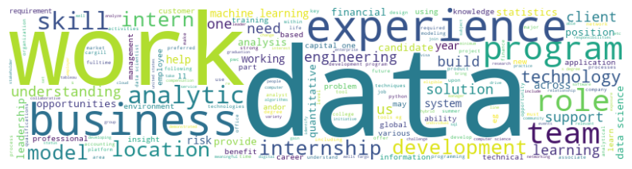

```python
# Create a wordcloud object and generate the word cloud
plot_wc(combined_str)
```

3. Create a wordcloud for the terms that start with the letter "a"

> Hint: Filter the data using something like this

```
term_frequency['term'].str.startswith('a')
```

[figure not shown]

```python
# Merge all elements to one string
words_start_with_a = [word for  word in term_df['term'] if word.startswith('a')]

words_start_with_a = ' '.join(words_start_with_a)

# Now plot wc with words that start with 'a' only

plot_wc(words_start_with_a)
```

4. Create a word cloud of companies

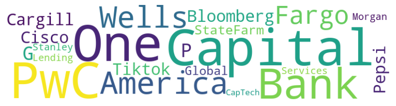

```python
# Get a string that contains all companies

firm_str = ' '.join(df_jobs['firm'])

# Create a worldcloud of companies

plot_wc(firm_str)
```

5. Create a word cloud of job titles.

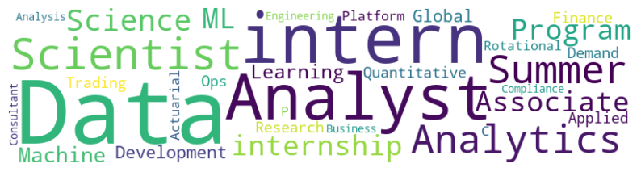

```python
# Get a string that contains all job titles

job_titles = ' '.join(df_jobs.title)

# Create a world cloud of all job titles

plot_wc(job_titles)
```

## Task 2 - Words after DATA

Clearly "DATA" an important word so what words come after data?

1. Create a bi-gram of Job Description terms starting with the word "Data", group by bigram and count them up into a `bigram_term_frequency` table. A good reference is the bigram example [here](https://colab.research.google.com/drive/1DdK_2Pn-LRSNnUhfuyBLEZlWvoFbffM_?usp=sharing).

```python
ngram_size = 2

# Extract bi-grams from teh full_text column

bigram_df = (df_jobs['job_description']
            .str.lower()
            .str.replace(f'[{string.punctuation}]', '')
            .str.split()
            .apply(lambda x: [word for word in x if word not in stop_words]) # remove stopwords before doing bigrams
            .apply(lambda x: list(ngrams(x, ngram_size)))
            .explode()
            .reset_index(drop = True)
            .to_frame('bigram')
            )
# Count them up into a bigram_term_frequency

bigram_term_frequency = bigram_df.groupby('bigram').size()
```

```python
# Create a mask to retain bigram that contain data only
mask_data = bigram_df['bigram'].apply(lambda x: True if x[0] == 'data' else False)

# filter the job desc
data_desc_df = bigram_df[mask_data]

# eye ball the first 5 rows
data_desc_df.head()
```

|  | bigram |
| --- | --- |
| 0 | (data, analyst) |
| 107 | (data, analyst) |
| 223 | (data, analyst) |
| 243 | (data, pioneer) |
| 258 | (data, science) |

2. Create a word cloud of data + term combinations, by filter the bigram_term_frequency for bigrams starting with “data”

```python
data_desc_df['bigram'].value_counts()
```

```
(data, science)       20
(data, analytics)      8
(data, scientist)      7
(data, sources)        7
(data, analysis)       7
                      ..
(data, objectives)     1
(data, processing)     1
(data, largescale)     1
(data, behavioral)     1
(data, fusion)         1
Name: bigram, Length: 70, dtype: int64
```

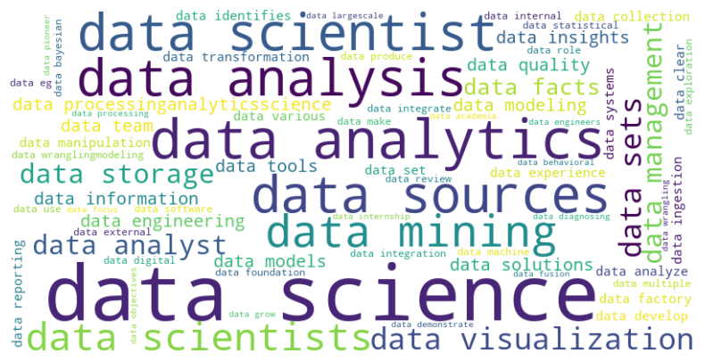

```python
data_wc = data_desc_df['bigram'].value_counts().reset_index()

data_wc.columns = ['bigram', 'Freq']

# reformat the bigram

data_wc['bigram_reformat'] = data_wc['bigram'].apply(lambda x: ' '.join([word for word in x]))

# Create a dictionary of terms and frequencies

dict_data_wc = dict(zip(data_wc['bigram_reformat'], data_wc['Freq']))

# Generate the word cloud

wordcloud = WordCloud(width=800, height=400, background_color='white').generate_from_frequencies(dict_data_wc)

# Display the word cloud

plt.figure(figsize=(10, 5))

plt.imshow(wordcloud, interpolation='bilinear')

plt.axis('off')

plt.show()
```

3. Create a bar chart of the top 10, data + term combinations.

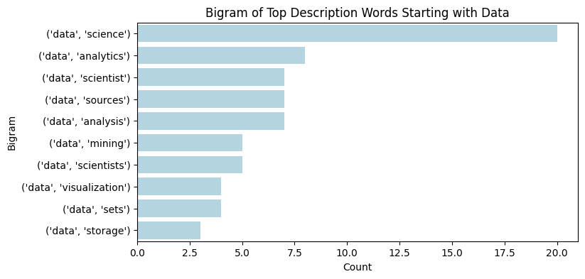

```python
data_top_terms = data_desc_df['bigram'].value_counts().nlargest(10).reset_index()

data_top_terms.columns = ['Bigram', 'Count']


plt.figure(figsize = (8,4))
sns.barplot(
    data = data_top_terms,
    x = 'Count',
    y = 'Bigram',
    color = 'lightblue'
)
plt.title('Bigram of Top Description Words Starting with Data')
plt.show()
```

## Task 3 - Analyze Technology

Here is a list of important technology terms - you of course should add more.

- creat 2 lists as shown below
- add any additional technology term or bigram that you think are useful.

```
technology_words = [
    "analytics",
    "data",
    "analyze",
    "r",
    "python",
    "sql",
    "excel",
    "cloud",
    "aws",
    "azure",
    "ec2",
    "sas",
    "spss",
    "saas",
    "spark",
    "tensorflow",
    "sagemaker",
    "tableau",
    "hadoop",
    "pyspark",
    "h2o.ai",
    "spark",
    "ai",
    "shiny",
    "dash",
    "pca",
    "k-means",
    "emr",
    "mapreduce",
    "nosql",
    "hive",
    "presentation",
    "nltk",
    "scikit",
    "javascript",
    "etl",
    'spacy',
    'pytorch',
    'bayes',
    'julia',
    'knn'
     ]


technology_bigrams = [
  "business intelligence",
  "text mining",
  "logistic regression",
  "amazon web",
  "big data",
  "business analytics",
  "google cloud",
  "microsoft azure",
  "machine learning",
  "data science",
  "deep learning",
  "neural network",
  "neural networks",
  "neural nets",
  "random forests",
  "random forest",
  "elastic search",
  "map reduce",
  "artificial intelligence",
  "decision tree",
  "linear regression",
  "associate rule",
  "grid search",
  "random search",
  "time series"
  ]
```

1. Filter the `term_frequency` table you made in task 1 based on the `technology_words` provided, resulting a new table `tech_term_freq`
2. Filter the `bigram_frequency` table you made in task 2 based on `technology_bigrams` provided, resulting a new table `tech_bigram_freq`
3. Smash the 2 tables together vertically as new table `technology_term_frequency` using `pd.concate()`

> Hint: only include 2 columns, "terms" and "freq"
4. Make a Bar Chart of top 10 Technolgy Terms.
5. Make a Wordcloud of all Techology Terms.

```python
technology_words = [
    "analytics",
    "data",
    "analyze",
    "r",
    "python",
    "sql",
    "excel",
    "cloud",
    "aws",
    "azure",
    "ec2",
    "sas",
    "spss",
    "saas",
    "spark",
    "tensorflow",
    "sagemaker",
    "tableau",
    "hadoop",
    "pyspark",
    "h2o.ai",
    "spark",
    "ai",
    "shiny",
    "dash",
    "pca",
    "k-means",
    "emr",
    "mapreduce",
    "nosql",
    "hive",
    "presentation",
    "nltk",
    "scikit",
    "javascript",
    "etl",
    'spacy',
    'pytorch',
    'bayes',
    'julia',
    'knn'
     ]
```

```python
technology_bigrams = [
  "business intelligence",
  "text mining",
  "logistic regression",
  "amazon web",
  "big data",
  "business analytics",
  "google cloud",
  "microsoft azure",
  "machine learning",
  "data science",
  "deep learning",
  "neural network",
  "neural networks",
  "neural nets",
  "random forests",
  "random forest",
  "elastic search",
  "map reduce",
  "artificial intelligence",
  "decision tree",
  "linear regression",
  "associate rule",
  "grid search",
  "random search",
  "time series"
  ]
```

```python
''' 1. Filter the term frequency table you made in task 1 based on the technology_words provided,
resulting a new table tech_term_freq'''

term_frequency_filtered = term_frequency.reset_index()

term_frequency_filtered.columns = ['Term',  'Frequency']

term_frequency_filtered = term_frequency_filtered[term_frequency_filtered['Term'].isin(technology_words)]

''' 2. Filter the bigram_frequency table that you made in task 2 based on technology_bigrams provided,
resulting a new table tech_bigram_freq.'''

bigram_term_freq = bigram_term_frequency.to_frame().reset_index()

# rename columns
bigram_term_freq.columns = ['Bigram', 'Frequency']

# remove () and ,

bigram_term_freq['Term'] = bigram_term_freq['Bigram'].apply(lambda x: ' '.join([word for word in x]))

# Filtered with technology_bigrams provided

tech_bigram_freq = bigram_term_freq[bigram_term_freq['Term'].isin(technology_bigrams)]
```

```python
''' 3. Smash the 2 tables together vertically'''

technology_term_freq = (pd.concat([tech_bigram_freq[['Term', 'Frequency']],
                        term_frequency_filtered[['Term', 'Frequency']]],
                        axis = 0))
```

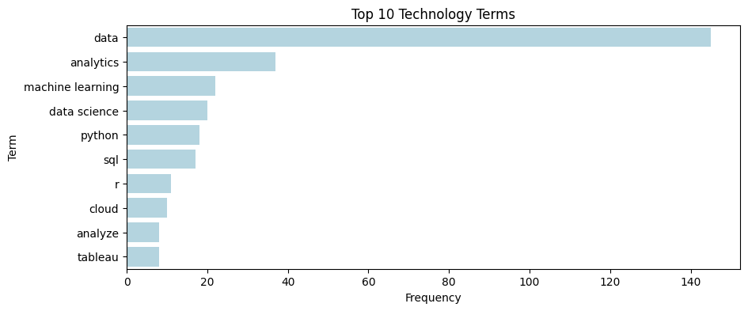

```python
# Make a bar chart of top 10 technology terms

plt.figure(figsize = (10,4))
sns.barplot(
    data = technology_term_freq.nlargest(10, 'Frequency'),
    x = 'Frequency',
    y = 'Term',
    color = 'lightblue')
plt.title('Top 10 Technology Terms')
plt.show()
```

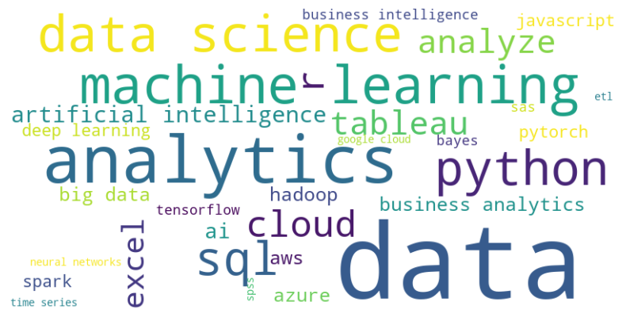

```python
# Make a wordcloud of all tech term
term_freq = dict(zip(technology_term_freq['Term'], technology_term_freq['Frequency']))

wordcloud = WordCloud(width=800, height=400, background_color='white').generate_from_frequencies(term_freq)

# Display the word cloud

plt.figure(figsize=(10, 5))

plt.imshow(wordcloud, interpolation='bilinear')

plt.axis('off')

plt.show()
```

## Task 4 - Your Resume

1. Save/print your resume as PDF, it needs to be PDF format for this to work.
2. Install pdfminer and import the function extract_text()
3. Use PdfReader to read your resume into a table. For example:

```
!pip install pdfminer.six
from pdfminer.high_level import extract_text

def extract_text_from_pdf(file_path):
    return extract_text(file_path)

text = extract_text_from_pdf('your_file.pdf')
print(text)

# Split text by rows and store them as a data frame
cv_df = pd.DataFrame({'cv_text': text.split('\n')})
```

4. Parse your resume, filter out the common words, digits, and any excludes
5. Create a word cloud of the remaining words in your resume
6. Filter for technology_words and technology_bigrams smash the results together (just like in task 3). To do this, you will need to
- create Words Freq and Bigram Freq based on your resume
- then filter for technology_words and technology_bigrams
7. Make a bar chart of top 10 combined technolgy term frequencies
8. Make a wordcloud of all combined technolgy term frequencies

```python
# 4. Parse my resume
from pdfminer.high_level import extract_text

def extract_text_from_pdf(file_path):
    return extract_text(file_path)

text = extract_text_from_pdf('Resume_Nam_Tran.pdf')

# # Split text by rows and store them as a data frame
cv_df = pd.DataFrame({'cv_text': text.split('\n')}) # Split text by row
```

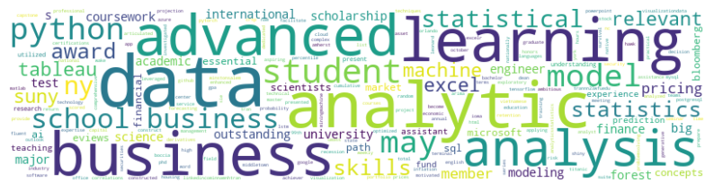

```python
# 5. Create a word cloud for the remaining words of my resume

# Filter out the common word, digits and excludes
cv_term = (cv_df['cv_text']
 .str.lower()
 .str.strip()
 .str.normalize('NFKD')
 .str.split()
 .explode()
 .str.replace(f"[{string.punctuation}]",'')
 .reset_index(drop = True)
 .to_frame('term')
)
 # additional terms for stopwords
stop_words.append('new')
stop_words.append('paltz')
stop_words.append(2023)
stop_words.append(2020)
# Create a mask
filter_mask = cv_term['term'].isin(stop_words)

# Filter out stop words

cv_term = cv_term[~filter_mask]

# Drop NA
cv_term = cv_term['term'].replace('', np.nan)

cv_term.dropna(inplace = True)

# Create a wordcloud from the remaining words in the resume

cv_term_str = ' '.join(cv_term.to_list())

plot_wc(cv_term_str)
```

```python
# 6. Filter for technology_words and technology_bigrams
##  6.1 Create Words Freq
cv_term_tech_wrd = cv_term.value_counts(ascending=False).reset_index()
cv_term_tech_wrd.columns = ['Term', 'Frequency']

cv_term_tech_wrd = cv_term_tech_wrd[cv_term_tech_wrd['Term'].isin(technology_words)]

print(cv_term_tech_wrd)
```

```
           Term  Frequency
1          data          9
5     analytics          6
9        python          5
17            r          4
18        excel          3
25      tableau          3
46          sql          2
57           ai          2
70        shiny          1
233       cloud          1
234       azure          1
235  tensorflow          1
236     pytorch          1
```

```python
## 6.2 Create CV bigrams

bigram_cv = (cv_df['cv_text']
            .str.lower()
            .str.replace(f'[{string.punctuation}]', '')
            .str.split()
            .apply(lambda x: [word for word in x if word not in stop_words]) # remove stopwords before doing bigrams
            .apply(lambda x: list(ngrams(x, ngram_size)))
            .explode()
            .reset_index(drop = True)
            .to_frame('bigram')
            )
bigram_cv.dropna(inplace = True)

bigram_cv = bigram_cv.value_counts(ascending=False).reset_index()

bigram_cv.columns = ['Bigram','Frequency']

# Create a column without ( ) and ,

bigram_cv['Term'] = bigram_cv['Bigram'].apply(lambda x: ' '.join(x))

# Filter for tech tech bigram words only

bigram_cv = bigram_cv[bigram_cv['Term'].isin(technology_bigrams)]

# combine it with cv_term_tech_wrd

combined_tech_term = pd.concat([cv_term_tech_wrd[['Term','Frequency']],
                                bigram_cv[['Term', 'Frequency']]],
                                axis = 0)

print(combined_tech_term)
```

```
                   Term  Frequency
1                  data          9
5             analytics          6
9                python          5
17                    r          4
18                excel          3
25              tableau          3
46                  sql          2
57                   ai          2
70                shiny          1
233               cloud          1
234               azure          1
235          tensorflow          1
236             pytorch          1
1    business analytics          4
3      machine learning          3
7              big data          2
40        random forest          1
54      microsoft azure          1
90          time series          1
243        google cloud          1
```

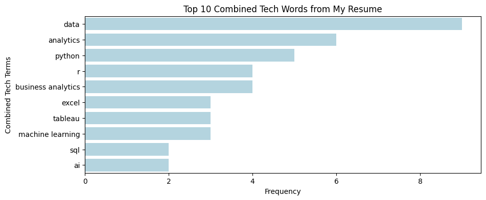

```python
# 7. Make a bar chart of top 10 combined technology term frequency

plt.figure(figsize = (10,4))
sns.barplot(
    data = combined_tech_term.nlargest(10, 'Frequency'),
    x = 'Frequency',
    y = 'Term',
    color = 'lightblue'
)
plt.ylabel('Combined Tech Terms')
plt.title('Top 10 Combined Tech Words from My Resume')
plt.show()
```

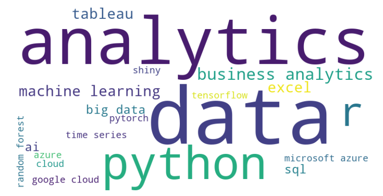

```python
# 8. Make a wordcloud for all the tech terms

## Convert the current data frame to a dictionary with term as key and frequency as values

combined_tech_term_dict = dict(zip(combined_tech_term['Term'], combined_tech_term['Frequency']))

wordcloud = WordCloud(width=800, height=400, background_color='white').generate_from_frequencies(combined_tech_term_dict)

# Display the word cloud

plt.figure(figsize=(10, 5))

plt.imshow(wordcloud, interpolation='bilinear')

plt.axis('off')

plt.show()
```

## Task 5 - Compare Resume vs Jobs

1. What terms do your resume and jobs data have in common? That is, compare your resume’s terms to the terms found in the job descriptions. Find the top 10 terms in common.

> Hint: `pd.merge(how='inner')` or how ever you want to do it.
2. Based on the job's terms, what terms are missing from your resume? Make a table of top 10 terms missing from your resume but found in your job descriptions.

> Hint: `pd.merge(how='left')` or how ever you want to do it.
3. What tech-skills does your resume and jobs have in common? Find the top 5 technology terms.

> Hint: `pd.merge(how='inner')` or filter `.isin()`
4. Based on the job's tech-skills, what are top 5 skills are missing from your resume?

> Hint: `pd.merge(how='left')` or filter not in

```python
cv_term = cv_term.to_frame('cv_term')
common_wrd = pd.merge(cv_term, term_df, how = 'inner', left_on = 'cv_term', right_on='term')
common_wrd = common_wrd['cv_term'].value_counts().nlargest(10)
print('Top 10 common words between my resume and the job description')
print(common_wrd.index)
```

```
Top 10 common words between my resume and the job description
Index(['data', 'business', 'learning', 'analytics', 'skills', 'experience',
       'analysis', 'may', 'python', 'statistics'],
      dtype='object')
```

```python
# 2. Based on the job's terms, what terms are missing from your resume?
# Make a table of top 10 terms missing from your resume but found in your job descriptions.

# Clean the blank space and some exclude words
term_df = term_df.replace('',np.nan).dropna()

exclude_words = [2024, 'one']

# remove the excluded words
term_df = term_df[~term_df['term'].isin(exclude_words)]

# top words in job description that is not in my resume
missing_words = term_df[~term_df['term'].isin(cv_term['cv_term'])].value_counts(ascending = False).nlargest(10).reset_index()

missing_words.columns = ['Term', 'Count']

print('Top 10 missing term from my resume')

print(missing_words)
```

```
Top 10 missing term from my resume
             Term  Count
0            work     71
1         program     51
2     development     39
3     information     35
4            team     35
5        computer     32
6            role     31
7          degree     30
8           tools     28
9  qualifications     27
```

```python
# 3. What tech-skills does your resume and jobs have in common? Find the top 5 technology terms.
top_tech_wrd = (term_df[term_df['term']
         .isin(combined_tech_term['Term']
         .to_list())].value_counts(ascending = False).nlargest(5).reset_index())
top_tech_wrd.columns = ['Term', 'Count']

print('Top 5 Tech skills that my resume and job description have in common')
print(top_tech_wrd)
```

```
Top 5 Tech skills that my resume and job description have in common
        Term  Count
0       data    145
1  analytics     37
2     python     18
3        sql     17
4          r     11
```

```python
# 4. What tech-skills that are missing from my resume

all_tech_wrd = technology_words + technology_bigrams

# Filter the tech words in job description

job_desc_tech_wrd = term_df[term_df['term'].isin(all_tech_wrd)]

# Retain terms that are missing out from our resume

missing_tech_wrd = job_desc_tech_wrd[~job_desc_tech_wrd.isin(combined_tech_term['Term'].to_list())].value_counts(ascending = False).nlargest(5).reset_index()

missing_tech_wrd.columns = ['Term', 'Count']
print('Top 5 Tech skills that are missing from my resume is')
print(missing_tech_wrd)
```

```
Top 5 Tech skills that are missing from my resume is
         Term  Count
0     analyze      8
1         aws      4
2      hadoop      4
3  javascript      3
4       spark      3
```

## Finally

Convert this to **HTML** and do you writeup in a **Word document**.